# USA Real Estate Data

Team 6

10/17/2022

# 1 Introduction

The USA has one of the hottest real estate markets right now. We needed a massive amount of data with various factors to know and analyze the real-estate data. Forecasting and evaluating the real estate market helps assess the stability of the US real estate market. Predicting home prices may also give a solid foundation for real estate investors to develop investment strategies and minimize losses. The issue arises when numerous variables, such as location and property demand, may influence the house price. Thus most stakeholders, including buyers and developers, home builders, and the real estate sector, would like to know the exact attributes or the specific factors that influence house prices to help customers and investors make decisions.

To get all this data, we got a scraped dataset from the website https://www.realtor.com (found on Kaggle). This dataset contains features like no. of beds, baths, streets, city, and zip code and has 923,160 observations. To get meaningful insights into this massive pile of data, we have to perform statistical analysis, Exploratory Data Analysis on the data set and visualize some of the observations.

This summary report is organised as follows -

1. Introduction
2. Description of the data
3. EDA: Insights from Visualization
4. Limitations and difficulties
5. Answering the SMART Questions
6. Conclusions
7. Links

## 1.1 Smart Questions

1. Which location contains the house with the highest and lowest prices?
2. What is the correlation between house price and other attributes?
3. Which is the most significant factor to be considered in house prices?
4. Does the mean price value affected by no. of beds and baths?

# 2 Description of the Data

## 2.1 Original Data

The dataset named “houseprices.csv” contains 923160 values and 12 variables. More details are shown below-

- status: Whether the house is sold or not.
- price: The price of the house
- bed: No. of beds in the house
- bath: No. of baths in the house
- acre_lot: The lot size in acres
- full_address: The address of the house
- street: The full address of the house spliced upto the street name.
- city: The full address of the house is spliced only to the city.
- state: The state in which the house is located
- zip_code: The zip code of the area in which the house is located
- house_size: The size of the house in sq. ft.
- sold_date: Mostly a null_value column as most houses are not sold yet.

The lowest price in the dataset is 3900 while the highest is 1625000. This means that there is much variance between the data. The mean of the price is 463442, and the standard deviation is 297437. The variance is 88468997450. The variance shows that the data is distributed very widely and spread out from the mean.

## 2.2 Preprocessing:

Our dataset is ready for preprocessing, so we executed the following steps:

1. We checked the number of null and duplicated values in the dataset; surprisingly, it was 84% of our dataset.
2. We then tried to replace the null values with the mean and median, but that killed the insights from our data as it is real-world and simply does not work in the way we expected.
3. We removed the following columns: full_address, street, zip_code, and sold_date. This was done because these variables in no way affected the output from the data and the correlation was also not great.
4. Then, we converted the bed and bath into factor variables from integer variables to work as intervals.
5. Finally, we were left with 42127 rows of data.
6. Our data is finally preprocessed and ready to perform EDA.

```
##      price              bed            bath         acre_lot
##  Min.   :   3900   Min.   :1.00   Min.   :1.00   Min.   :0.000
##  1st Qu.: 250000   1st Qu.:3.00   1st Qu.:2.00   1st Qu.:0.090
##  Median : 385000   Median :3.00   Median :2.00   Median :0.190
##  Mean   : 463442   Mean   :3.35   Mean   :2.26   Mean   :0.375
##  3rd Qu.: 599999   3rd Qu.:4.00   3rd Qu.:3.00   3rd Qu.:0.460
##  Max.   :1625000   Max.   :7.00   Max.   :4.00   Max.   :2.410
##      city              state              zip_code       house_size
##  Length:42127       Length:42127       Min.   :  601   Min.   : 122
##  Class :character   Class :character   1st Qu.: 4963   1st Qu.:1238
##  Mode  :character   Mode  :character   Median : 8009   Median :1657
##                                        Mean   : 8705   Mean   :1819
##                                        3rd Qu.:10707   3rd Qu.:2261
##                                        Max.   :95652   Max.   :4515
```

# 3 EDA

To perform EDA in our dataset, we first need to know the relationship between our dependent and independent variables. So we built some graphs between our dependent(Price) and independent variables(everything else).

## 3.1 Visualization

First, we need to know what the distribution of the variables. So, we created a graph which shows the frequency of the house size:

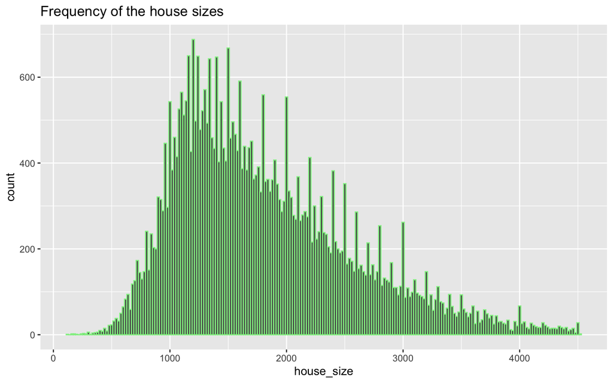

Here, we can understand that most of the houses in the dataset are medium-sized houses in the market. So, to check the acre _lot for these medium-sized houses, we create a similar histogram for the dataset.

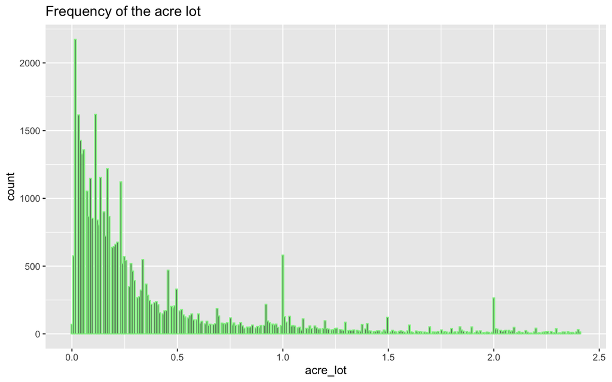

Here we can see that even for medium-sized houses, the acre_lot is very low. This means the house can be famous in the market if people have parking for one car and a small lawn.

Next, we need to analyze the relationship between dependent and independent variables. First, we need to see the relationship between house size and house price.

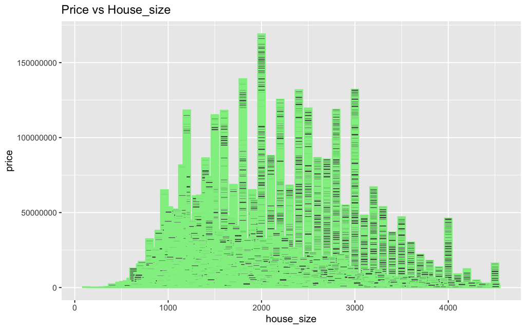

We can observe that even though the size of the house is increasing drastically, the price of the house is not increasing in tandem with the size of the house. This means that some more significant factors affect the price of the house.

To find these factors, we did the bar plot between the dependent and independent variables.

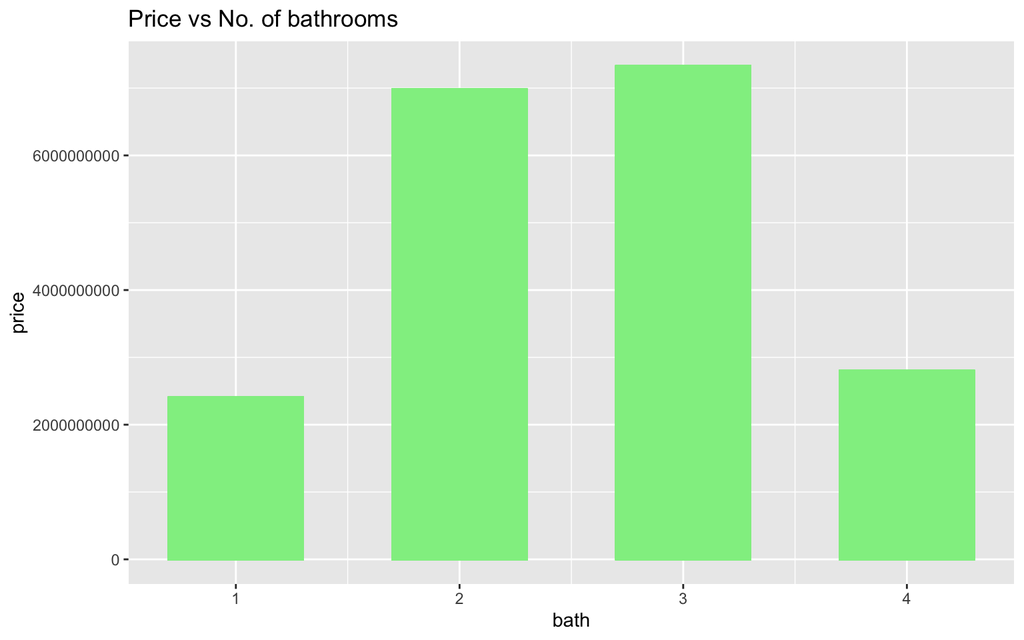

Next, the graph is between no. of bedrooms and the price of the house.

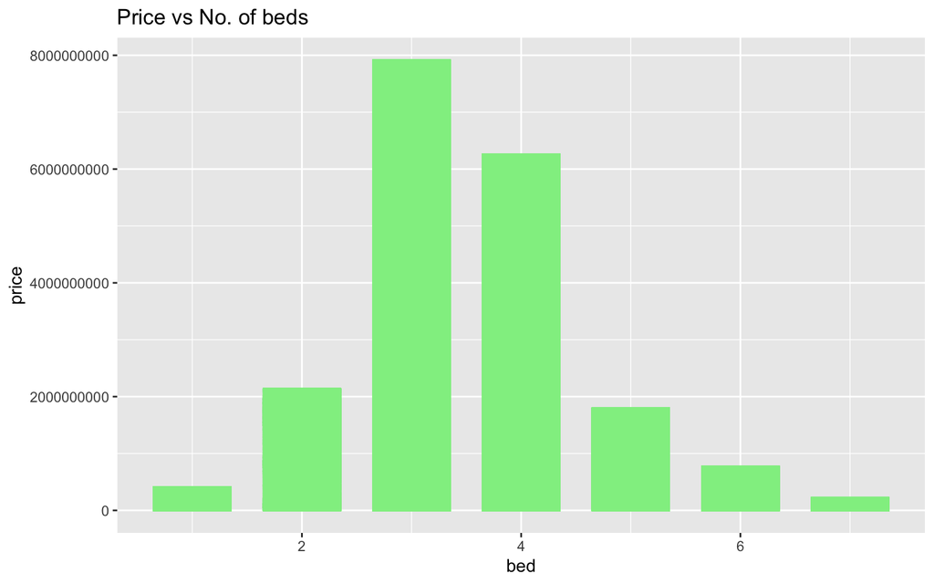

Now, the only independent variable left is the area of the house. So, to plot the graph between the price of the house and the area of the house.

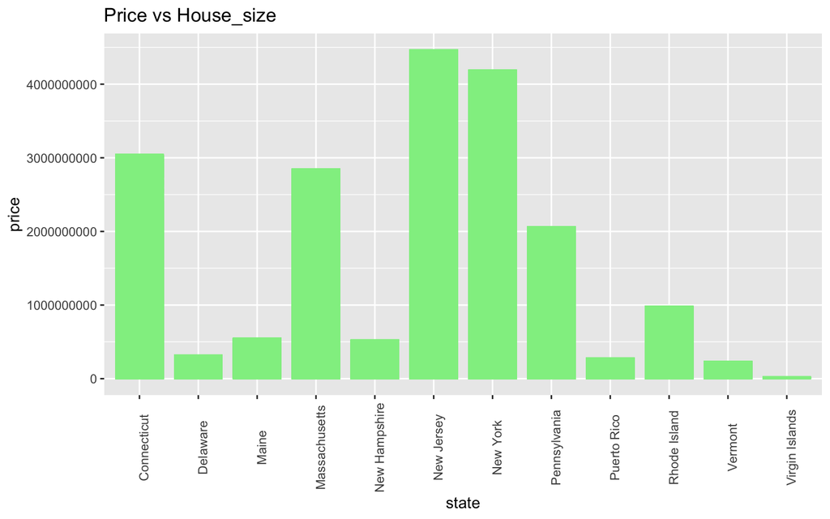

We wanted to determine each state’s mathematical values separately, such as mean, median, and standard deviation. So we used the dplyr function to group the data by states and calculate the values.

First we visualized the data between the mean price and the state.

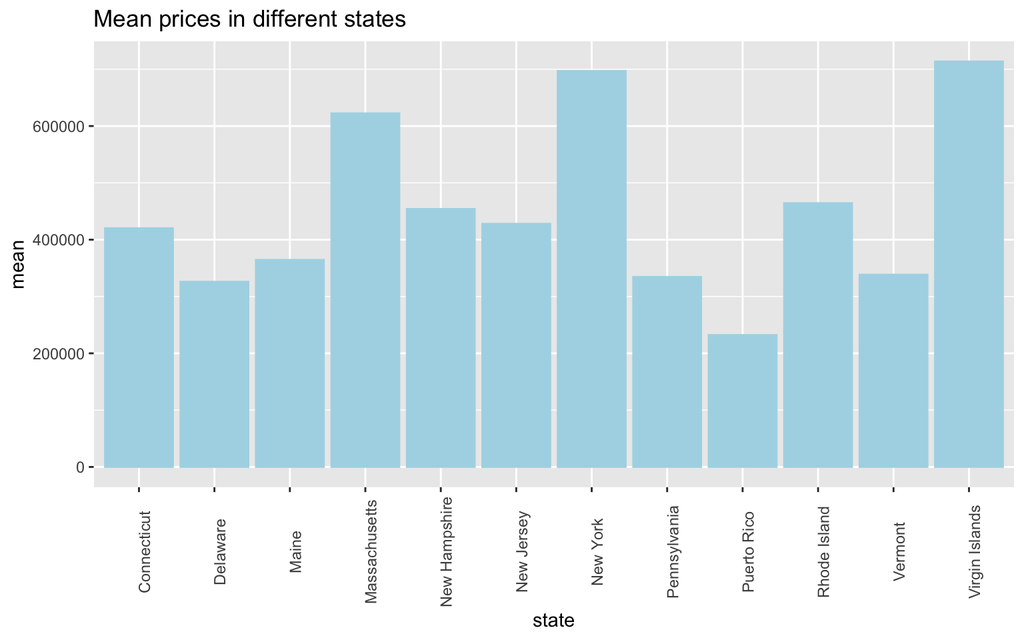

Similarly, the graph of the median price in states is as follows:

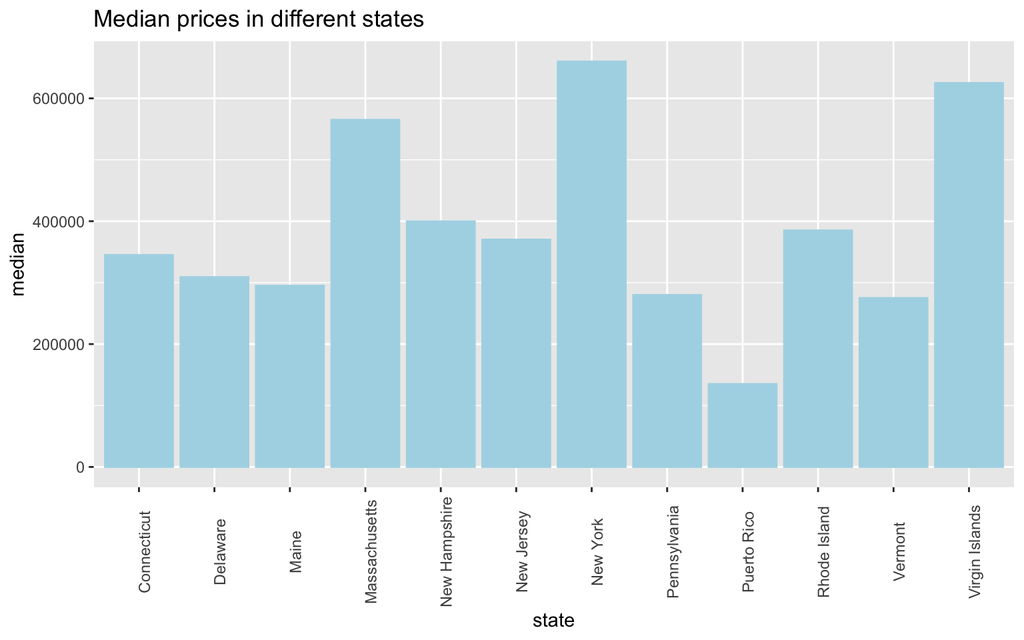

The median prices of different states show that the highest median price is in New York City. This shows us how much the prices in New York are.

We also did a similar graph for each states standard deviation of prices. This will show us the distribution of prices from the mean.

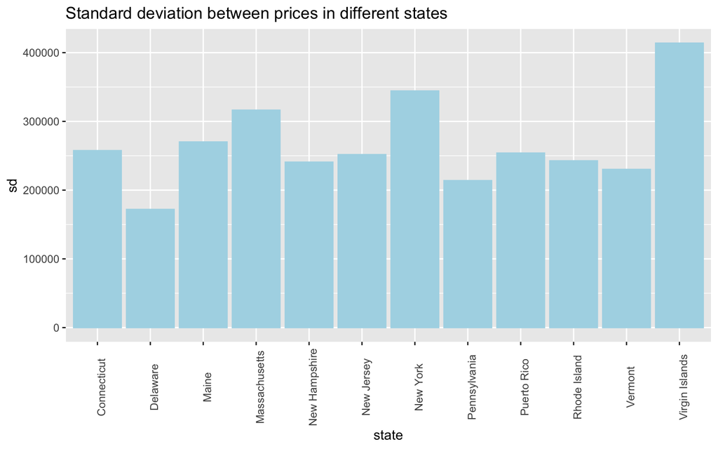

This graph shows that the deviation from the mean is the highest in the Virgin Islands, where the difference between the lowest and the highest prices is very high. The deviation from the mean is also very high in the Virgin Islands. This speaks to the geography of the state.

## 3.2 Testing

### 3.2.1 Tukey-HSD test

```
##                Df           Sum Sq        Mean Sq F value              Pr(>F)
## factor(bed)     6  321639924212049 53606654035342     663 <0.0000000000000002
## Residuals   42120 3405205062356822    80845324367
##
## factor(bed) ***
## Residuals
## ---
## Signif. codes:  0 '***' 0.001 '**' 0.01 '*' 0.05 '.' 0.1 ' ' 1
```

Model: price ~ factor(bed)

|  | Df | Sum Sq | Mean Sq | F value | Pr(>F) |
| --- | --- | --- | --- | --- | --- |
| factor(bed) | 6 | 321639924212049 | 53606654035342 | 663 | 0 |
| Residuals | 42120 | 3405205062356822 | 80845324367 | NA | NA |

```
##   Tukey multiple comparisons of means
##     95% family-wise confidence level
##
## Fit: aov(formula = price ~ factor(bed), data = df)
##
## $`factor(bed)`
##       diff     lwr    upr p adj
## 2-1 -80766 -110135 -51397 0.000
## 3-1 -28207  -56163   -250 0.046
## 4-1 121110   92686 149535 0.000
## 5-1 189792  158323 221262 0.000
## 6-1 111972   76701 147242 0.000
## 7-1 164882  113556 216208 0.000
## 3-2  52560   40164  64955 0.000
## 4-2 201876  188460 215293 0.000
## 5-2 270559  251521 289596 0.000
## 6-2 192738  167917 217559 0.000
## 7-2 245648  200855 290442 0.000
## 4-3 149317  139365 159269 0.000
## 5-3 217999  201222 234776 0.000
## 6-3 140178  117046 163311 0.000
## 7-3 193089  149209 236969 0.000
## 5-4  68682   51137  86227 0.000
## 6-4  -9139  -32834  14557 0.917
## 7-4  43772    -408  87951 0.054
## 6-5 -77821 -105095 -50547 0.000
## 7-5 -24910  -71108  21288 0.689
## 7-6  52911    4045 101777 0.024
```

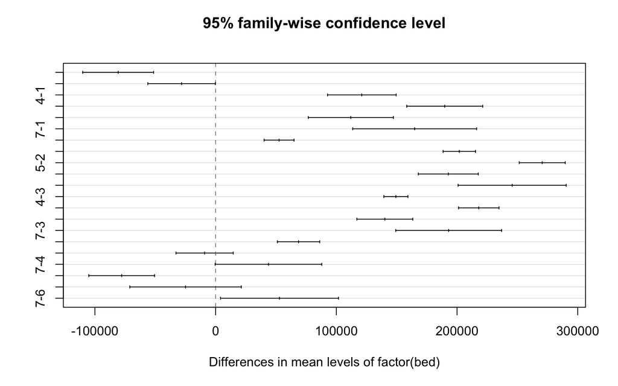

```
##                 Df           Sum Sq         Mean Sq F value              Pr(>F)
## factor(bath)     3  931814596551079 310604865517026    4681 <0.0000000000000002
## Residuals    42123 2795030390017876     66354020132
##
## factor(bath) ***
## Residuals
## ---
## Signif. codes:  0 '***' 0.001 '**' 0.01 '*' 0.05 '.' 0.1 ' ' 1
```

Model: price ~ factor(bath)

|  | Df | Sum Sq | Mean Sq | F value | Pr(>F) |
| --- | --- | --- | --- | --- | --- |
| factor(bath) | 3 | 931814596551079 | 310604865517026 | 4681 | 0 |
| Residuals | 42123 | 2795030390017876 | 66354020132 | NA | NA |

```
##   Tukey multiple comparisons of means
##     95% family-wise confidence level
##
## Fit: aov(formula = price ~ factor(bath), data = df)
##
## $`factor(bath)`
##       diff    lwr    upr p adj
## 2-1 126415 117731 135099     0
## 3-1 312859 303620 322098     0
## 4-1 506393 493265 519521     0
## 3-2 186444 178673 194215     0
## 4-2 379978 367838 392118     0
## 4-3 193534 180991 206077     0
```

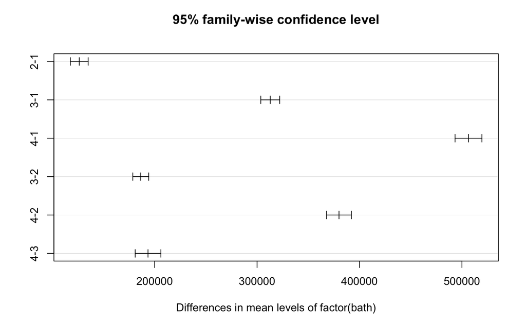

H0: The mean house prices are the same across the different numbers of baths. H1: The mean house prices are different across the different numbers of baths. The ANOVA test for the house price and the number of bathrooms indicates that the p-value is less than 0.05. So we need to reject the null hypothesis, and the mean price of the houses is different from the number of baths. From the Tukey test, the pairwise comparison between each group is statistically significant at a 95% confidence interval.

### 3.2.2 Chi test

Contingency table for beds vs baths in house_dataframe

| 1 | 2 | 3 | 4 |
| --- | --- | --- | --- |
| 801 | 133 | 6 | 3 |
| 2767 | 2653 | 532 | 39 |
| 4447 | 9314 | 4904 | 672 |
| 628 | 3939 | 5024 | 1617 |
| 71 | 814 | 1206 | 776 |
| 11 | 444 | 601 | 353 |
| 1 | 67 | 179 | 125 |

```
##
##  Pearson's Chi-squared test
##
## data:  contable
## X-squared = 12393, df = 18, p-value <0.0000000000000002
```

One of the main limitations of this dataset is that the number of N/A values is massive among different columns. If we remove all of the N/A values in the data frame, too few datasets will be left for our analysis. In this case, we remove the N/A values of the specific columns we are interested in different tests. For example, if we look for the linear regression between house price and the number of beds, all the N/A values in these two columns would be removed accordingly, and the remaining columns will keep the same.

Secondly, our dataset does not include a concrete ‘time’ column for the listing housings, so we cannot perform any predictive analysis.

# 4 Answering the SMART questions

## 4.1 Which location contains the house with the highest and lowest prices?

The boxplot shows that New York and the Virgin Islands ranked the highest housing prices among all the states. Let us see the specific data summary. The range of housing prices in the Virgin Islands is from a maximum of $1,475,000 to a minimum of $135,000, which is smaller than New York ranging from $1,625,000 to $20,000 which is a pretty shocking fact that the wealth gap in New York has massively differed from place to place. At the same time, we can tell the vast gap between the poor and the wealthy from the outliers indicated in the box chart that New York has an unbalanced income gap among the buyers.

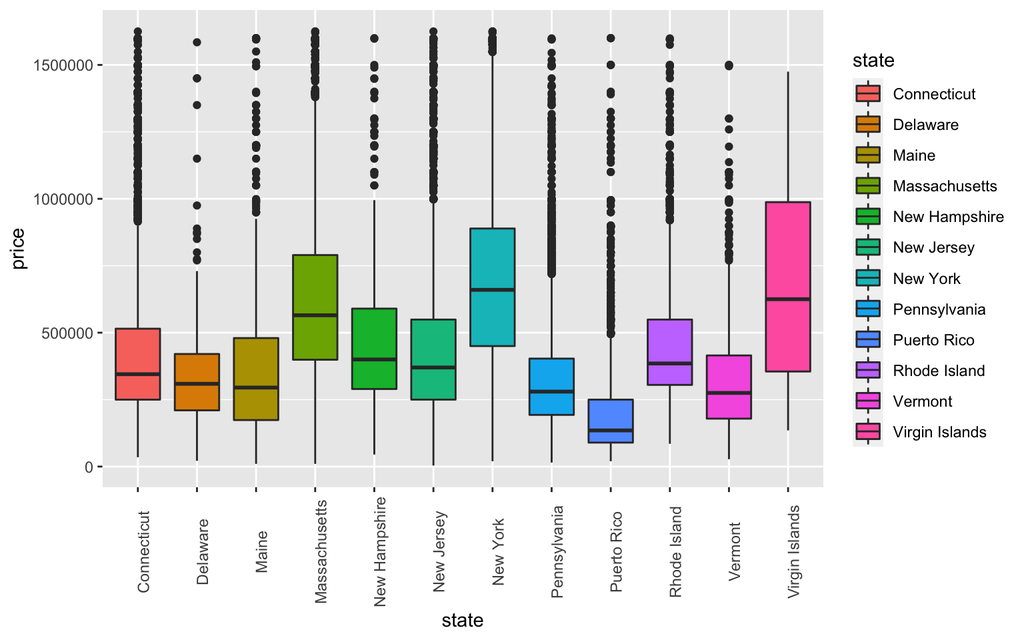

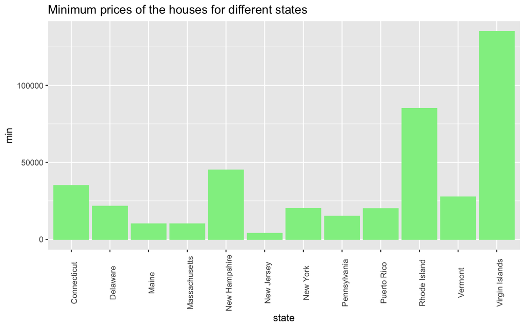

## 4.2 What is the correlation between house price and other attributes?

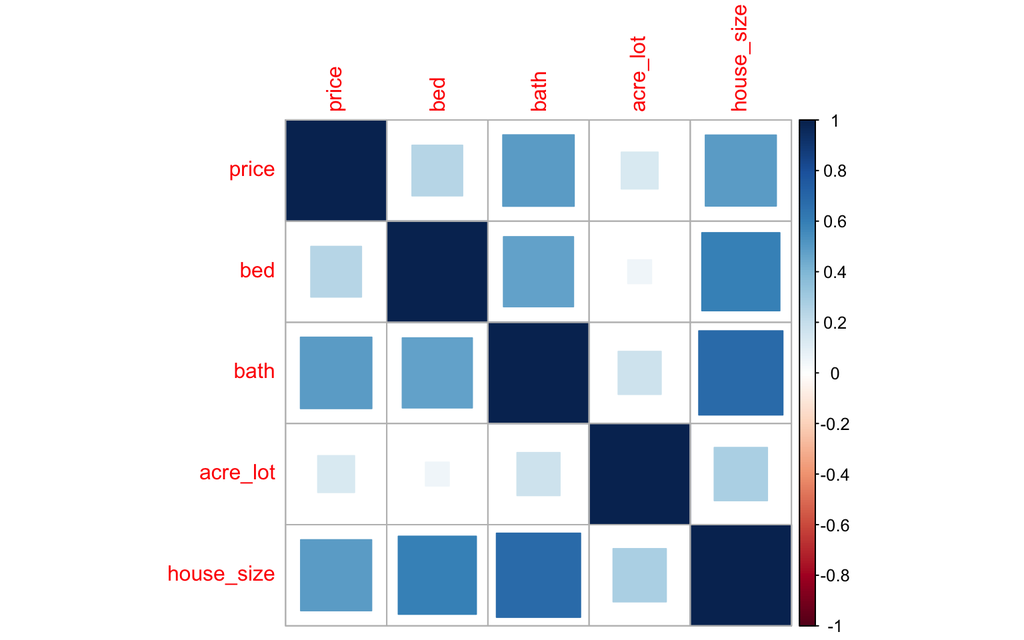

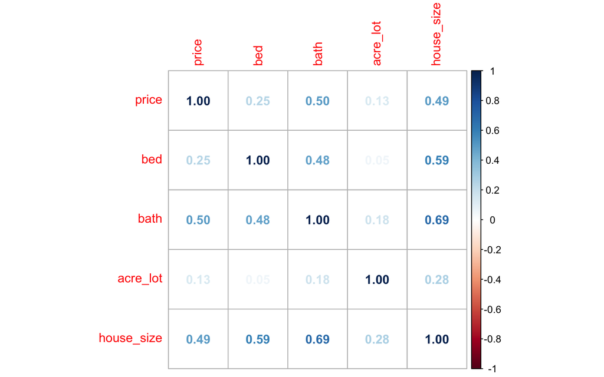

## 4.3 Which is the most significant factor to be considered in house prices?

According to our correlation graph, we build up the first linear model between price and bed.

There is a 6.23% variability in price being explained by the beds in this linear model. Variation in y (price) is 6.23%, explained by x (bed). The value is relatively low to explain everything.

The Intercept value is at b = 224994, about 47.68 std err away from zero, with p-value 2⨉10−16. It is tiny, meaning it is very significant (to reject the null hypothesis that b = 0), as seen from the three asterisks.

The slope/coefficient for bed is at b1 = 71160, about 52.92 std err away from zero, with p-value 2⨉10−16. Again, this is extremely small, meaning it is significant (to reject the null hypothesis that b1 = 0). So we are very confident that bed has a positive correlation with price.

```
##
## Call:
## lm(formula = price ~ bed, data = df)
##
## Residuals:
##     Min      1Q  Median      3Q     Max
## -698217 -198475  -67415  139364 1328845
##
## Coefficients:
##             Estimate Std. Error t value            Pr(>|t|)
## (Intercept)   224994       4719    47.7 <0.0000000000000002 ***
## bed            71160       1345    52.9 <0.0000000000000002 ***
## ---
## Signif. codes:  0 '***' 0.001 '**' 0.01 '*' 0.05 '.' 0.1 ' ' 1
##
## Residual standard error: 288000 on 42125 degrees of freedom
## Multiple R-squared:  0.0623, Adjusted R-squared:  0.0623
## F-statistic: 2.8e+03 on 1 and 42125 DF,  p-value: <0.0000000000000002
```

According to our correlation graph, we build up the second linear model between price and bath.

The Intercept value is at b = 84812, about 24.5 std err away from zero, with p-value 2⨉10−16. It is minimal, meaning it is very significant (to reject the null hypothesis that b = 0), as seen from the three asterisks.

The slope/coefficient for the bath is at b1 = 167636, about 117.4 std err away from zero, with a p-value of 2⨉10−16. Again, this is extremely small, meaning it is significant (to reject the null hypothesis that b1 = 0). So we are very confident that bath has a positive correlation with price.

```
##
## Call:
## lm(formula = price ~ bath, data = df)
##
## Residuals:
##     Min      1Q  Median      3Q     Max
## -727854 -167448  -52719  107281 1372552
##
## Coefficients:
##             Estimate Std. Error t value            Pr(>|t|)
## (Intercept)    84812       3461    24.5 <0.0000000000000002 ***
## bath          167636       1428   117.4 <0.0000000000000002 ***
## ---
## Signif. codes:  0 '***' 0.001 '**' 0.01 '*' 0.05 '.' 0.1 ' ' 1
##
## Residual standard error: 258000 on 42125 degrees of freedom
## Multiple R-squared:  0.247,  Adjusted R-squared:  0.247
## F-statistic: 1.38e+04 on 1 and 42125 DF,  p-value: <0.0000000000000002
```

There is a 24.68% variability in price explained by a bed in this linear model. Variation in y (price) is 24.68%, explained by x1 (bed) and x2 (bath). The value is relatively higher than the model1 to explain everything.

The Intercept value is at b = 75370, about 16.828 std err away from zero, with p-value 2⨉10−16. It is minimal, meaning it is very significant (to reject the null hypothesis that b = 0), as seen from the three asterisks.

The slope/coefficient for bed is at b1 = 4557, about 3.321 std err away from zero, with a p-value of 0.000896. Again, this is extremely small, meaning it is very significant. So we are very confident that bed has a positive correlation with price.

The slope/coefficient for the bath is at b1 = 165055, about 101.555 std err away from zero, with a p-value 2⨉10−16. Again, this is extremely small, meaning it is very significant. So we are very confident that bed and bath positively correlate with price.

```
##
## Call:
## lm(formula = price ~ bed + bath, data = df)
##
## Residuals:
##     Min      1Q  Median      3Q     Max
## -721762 -164982  -54097  105848 1380018
##
## Coefficients:
##             Estimate Std. Error t value            Pr(>|t|)
## (Intercept)    75370       4479   16.83 <0.0000000000000002 ***
## bed             4557       1372    3.32              0.0009 ***
## bath          165055       1625  101.55 <0.0000000000000002 ***
## ---
## Signif. codes:  0 '***' 0.001 '**' 0.01 '*' 0.05 '.' 0.1 ' ' 1
##
## Residual standard error: 258000 on 42124 degrees of freedom
## Multiple R-squared:  0.247,  Adjusted R-squared:  0.247
## F-statistic: 6.9e+03 on 2 and 42124 DF,  p-value: <0.0000000000000002
```

We now develop the ANOVA test to indicate which model is the most suitable for the data frame; model 3 is the fittest model among the three models, as seen from the three asterisks.

```
## Analysis of Variance Table
##
## Model 1: price ~ bed
## Model 2: price ~ bath
## Model 3: price ~ bed + bath
##   Res.Df              RSS Df       Sum of Sq  F Pr(>F)
## 1  42125 3494484778003061
## 2  42125 2807926157983326  0 686558620019734
## 3  42124 2807190968904712  1    735189078615 11 0.0009 ***
## ---
## Signif. codes:  0 '***' 0.001 '**' 0.01 '*' 0.05 '.' 0.1 ' ' 1
```

ANOVA comparison between the models

| Res.Df | RSS | Df | Sum of Sq | F | Pr(>F) |
| --- | --- | --- | --- | --- | --- |
| 42125 | 3494484778003061 | NA | NA | NA | NA |
| 42125 | 2807926157983326 | 0 | 686558620019734 | NA | NA |
| 42124 | 2807190968904712 | 1 | 735189078615 | 11 | 0.0009 |

The Variance Inflation Factor VIF measures how good/bad two regressors (*x*-variables) are correlated to others. And the Vif we have for model three is 1.3, which variables are mildly correlated, and that is considered to be great where it is between 1 < vif < 5(the rule of thumb)

VIFs of Model: price ~ bed + bath

| bath | bed |
| --- | --- |
| 1.3 | 1.3 |